# Coursera Practical Machine Learning Course Project

# Machine Learning

## Training with decision trees

We first build a simple machine learning prediction using decision trees.

```r
# Predicting with trees
modFitTree <- train(classe ~ ., method = "rpart", data = subTraining)
# Looking at the treeqpl predicted
print(modFitTree$finalModel)
```

```
## n= 14718
##
## node), split, n, loss, yval, (yprob)
##       * denotes terminal node
##
##  1) root 14718 10533 A (0.28 0.19 0.17 0.16 0.18)
##    2) roll_belt< 130.5 13473  9298 A (0.31 0.21 0.19 0.18 0.11)
##      4) pitch_forearm< -34.35 1167     5 A (1 0.0043 0 0 0) *
##      5) pitch_forearm>=-34.35 12306  9293 A (0.24 0.23 0.21 0.2 0.12)
##       10) magnet_dumbbell_y< 438.5 10423  7472 A (0.28 0.18 0.24 0.19 0.11)
##         20) roll_forearm< 123.5 6483  3841 A (0.41 0.18 0.18 0.17 0.062) *
##         21) roll_forearm>=123.5 3940  2616 C (0.078 0.18 0.34 0.23 0.18) *
##       11) magnet_dumbbell_y>=438.5 1883   920 B (0.033 0.51 0.042 0.22 0.19) *
##    3) roll_belt>=130.5 1245    10 E (0.008 0 0 0 0.99) *
```

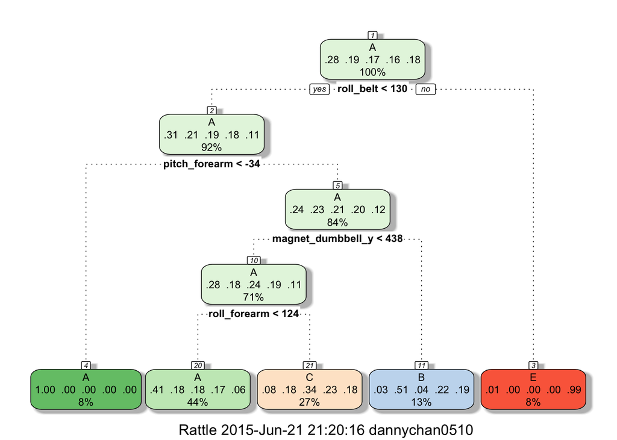

```r
# Plotting the plot tree
fancyRpartPlot(modFitTree$finalModel)
```

We use the cross-validation testing dataset to test the prediction from the decision tree.

```r
# Generating predictions from decision tree
prediction_modFitTree <- predict(modFitTree, newdata = subTesting)
confusionMatrix(prediction_modFitTree, subTesting$classe)
```

```
## Confusion Matrix and Statistics
##
##           Reference
## Prediction    A    B    C    D    E
##          A 1269  390  423  345  123
##          B   25  330   29  154  130
##          C   97  229  403  305  252
##          D    0    0    0    0    0
##          E    4    0    0    0  396
##
## Overall Statistics
##
##                Accuracy : 0.489
##                  95% CI : (0.4749, 0.5031)
##     No Information Rate : 0.2845
##     P-Value [Acc > NIR] : < 2.2e-16
##
##                   Kappa : 0.332
##  Mcnemar's Test P-Value : NA
##
## Statistics by Class:
##
##                      Class: A Class: B Class: C Class: D Class: E
## Sensitivity            0.9097  0.34773  0.47135   0.0000  0.43951
## Specificity            0.6349  0.91454  0.78192   1.0000  0.99900
## Pos Pred Value         0.4976  0.49401  0.31337      NaN  0.99000
## Neg Pred Value         0.9465  0.85387  0.87507   0.8361  0.88788
## Prevalence             0.2845  0.19352  0.17435   0.1639  0.18373
## Detection Rate         0.2588  0.06729  0.08218   0.0000  0.08075
## Detection Prevalence   0.5200  0.13622  0.26223   0.0000  0.08157
## Balanced Accuracy      0.7723  0.63114  0.62663   0.5000  0.71926
```

We get an accuracy of 0.489 - not bad, but we could definitely do better. The decision tree was particularly bad at predicting Class D - it did not land any predictions in Class D.

## Training with Random Forests

Let us now predict using a Random Forest algorithm. Again, we build the Random Forest model using the training dataset from the cross validation.

```r
# Predicting with Random Forests
modFitRF <- train(classe ~ ., method = "rf", data = subTraining)
prediction_modFitRF <- predict(modFitRF, newdata = subTesting)
confusionMatrix(prediction_modFitRF, subTesting$classe)
```

```
## Confusion Matrix and Statistics
##
##           Reference
## Prediction    A    B    C    D    E
##          A 1392    5    0    0    0
##          B    3  940    4    0    0
##          C    0    4  847   12    2
##          D    0    0    4  791    3
##          E    0    0    0    1  896
##
## Overall Statistics
##
##                Accuracy : 0.9923
##                  95% CI : (0.9894, 0.9945)
##     No Information Rate : 0.2845
##     P-Value [Acc > NIR] : < 2.2e-16
##
##                   Kappa : 0.9902
##  Mcnemar's Test P-Value : NA
##
## Statistics by Class:
##
##                      Class: A Class: B Class: C Class: D Class: E
## Sensitivity            0.9978   0.9905   0.9906   0.9838   0.9945
## Specificity            0.9986   0.9982   0.9956   0.9983   0.9998
## Pos Pred Value         0.9964   0.9926   0.9792   0.9912   0.9989
## Neg Pred Value         0.9991   0.9977   0.9980   0.9968   0.9988
## Prevalence             0.2845   0.1935   0.1743   0.1639   0.1837
## Detection Rate         0.2838   0.1917   0.1727   0.1613   0.1827
## Detection Prevalence   0.2849   0.1931   0.1764   0.1627   0.1829
## Balanced Accuracy      0.9982   0.9944   0.9931   0.9911   0.9971
```

This is much better - using Random Forests, we get an accuracy rate of 0.9923

# Conclusion

As expected, the Random Forest algorithm performed better than Decision Trees. Accuracy for Random Forest model was 0.9923 (95% CI: (0.9894, 0.9945)) compared to 0.489 (95% CI: (0.4749, 0.5031)) for Decision Tree model. Therefore we choose the Random Forest algorithm is choosen. The accuracy of the model is 0.9923. The expected out-of-sample error is estimated at 0.0077, or 0.77%. The expected out-of-sample error is calculated as 1 - accuracy for predictions made against the cross-validation set. Our Test data set comprises 20 cases. With an accuracy above 99% on our cross-validation data, we can expect that very few, or none, of the test samples will be missclassified.

# Generating Submission Files

We first generate the predictions using the actual test dataset, and then prepare the files to submit.

```r
# Predict outcome levels on the original Testing data set using Random Forest algorithm
predictfinal <- predict(modFitRF, newdata = test)
predictfinal
```

```
##  [1] B A B A A E D B A A B C B A E E A B B B
## Levels: A B C D E
```

```r
# Write files for submission
pml_write_files = function(x){
  n = length(x)
  for(i in 1:n){
    filename = paste0("problem_id_",i,".txt")
    write.table(x[i],file=filename,quote=FALSE,row.names=FALSE,col.names=FALSE)
  }
}

pml_write_files(predictfinal)
```